# Piru_enhancement_seedlingsurvival

Stephanie Ma Lucero

2023-02-25

# Load libraries

```r
library(here) # similar to set working directory
library(dplyr) # includes functions:
library(tidyverse) # data wrangling, includes packages: ggplot2, tibble, tidyr, rear, purrr, stringr, forcats
library(lme4)
library(lmerTest)
library(emmeans)
```

# Load colors for graphs

```r
devtools::install_github("an-bui/calecopal")
library(calecopal)
# all palettes
names(cal_palettes)
```

```
##  [1] "sierra1"      "sierra2"      "chaparral1"   "chaparral2"   "chaparral3"
##  [6] "conifer"      "desert"       "wetland"      "oak"          "kelp1"
## [11] "kelp2"        "coastaldune1" "coastaldune2" "superbloom1"  "superbloom2"
## [16] "superbloom3"  "sbchannel"    "lake"         "fire"         "agriculture"
## [21] "bigsur"       "figmtn"       "caqu"         "eschscholzia" "arbutus"
## [26] "calochortus"  "grassdry"     "grasswet"     "sage"         "tidepool"
## [31] "seagrass"     "bigsur2"      "bixby"        "redwood1"     "redwood2"
## [36] "halfdome"     "creek"        "vermillion"   "canary"       "casj"
## [41] "lupinus"      "dudleya"      "gayophytum"   "collinsia"    "buow"
```

```r
# Site colors: 1, 2
cal_palette(name = "chaparral1", n = 5, type = "continuous") # [1] "#DCC27A" "#F19B34"
```

```
## [1] "#DCC27A" "#9CA2A6" "#7D5F5D" "#A8A694" "#F19B34"
## attr(,"class")
## [1] "palette"
## attr(,"name")
## [1] "chaparral1"
```

```r
site1color <- "#DCC27A"
site2color <- "#F19B34"
sitecolors <- c(site1color, site2color)

# Treatment colors: Full, half, none
cal_palette(name = "chaparral3", n = 5, type = "continuous") # [1] "#D3E3CA", "#92A587", "#2F3525"
```

```
## [1] "#D3E3CA" "#BED6B3" "#92A587" "#4A5438" "#2F3525"
## attr(,"class")
## [1] "palette"
## attr(,"name")
## [1] "chaparral3"
```

```r
cal_palette(name = "desert", n = 5, type = "continuous") # [1] "#F6EECF", "#B09175", "#291611"
```

```
## [1] "#F6EECF" "#ECD6AB" "#B09175" "#632D1F" "#291611"
## attr(,"class")
## [1] "palette"
## attr(,"name")
## [1] "desert"
```

```r
treatment1color <- "#F6EECF"
treatment2color <- "#B09175"
treatment3color <- "#291611"
treatmentcolors <- c(treatment1color, treatment2color, treatment3color)
```

# Question 2: How does seedling survival change with PAR, TDR, % nn cover, and species?

Notes: * **response variable**: The variable you want to test. (e.g.,. PAR, TDR, nncover) * **explanatory variables**: The variables that can explain the outcome. (e.g., treatment, mafacover, site) * **data frame**: Include all the data you’ll be working with. (e.g., combine par and mafa_cover_all) * **formula**: a formula is a two-sided linear formula object describing both the *fixed-effects* and *random effects* part of the model, with the response on the left of a ~ operator and the terms, separated by + operators, on the right. * **random effects**: Random-effects terms are distinguished by vertical bars **(|)** separating expressions for design matrices from grouping factors. Two vertical bars **(||)** can be used to specify multiple uncorrelated random effects for the same grouping variable. + Because of the way it is implemented, the ||-syntax works only for design matrices containing numeric (continuous) predictors; to fit models with independent categorical effects, see dummy or the lmer_alt function from the afex package.)

### Load PAR, TDR, and non-native percent cover data.

### Saved as a csv in the “Processed” data folder.

```r
# survival and mortality data
survmort_load <- read_csv("data/processed/survmort.csv",
                      col_types = cols(
                        year = col_character(),
                        month = col_integer(),
                        site = col_character(),
                        plot_number = col_character(),
                        treatment = col_character(),
                        species = col_character(),
                        alive = col_integer(),
                        dead = col_integer(),
                        month_count = col_integer(),
                        transplanted = col_character()
                      )
                        )
# survival and mortality data WITH species
survmort <- survmort_load %>%
  dplyr::select(year, month, plot_number, treatment, species, alive, dead, site, month_count, transplanted) # %>%
#  mutate(treatment = recode(treatment, no = "none"))

# survival and mortality data WITHOUT species
survmortnospp <- survmort_load %>%
  dplyr::select(year, month, plot_number, treatment, alive, dead, site, month_count, transplanted) %>%
 # mutate(treatment = recode(treatment, no = "none")) %>%
  group_by(year, month, site, plot_number, treatment, month_count, transplanted) %>%
  summarize(totalsurvival = sum(alive),
            totalmortality = sum(dead)) %>%
  ungroup()
```

[output not shown]

```r
print(survmortnospp) # :) yay! it worked!
```

```
## # A tibble: 504 × 9
##    year  month site  plot_number treatment month_count transpl…¹ total…² total…³
##    <chr> <int> <chr> <chr>       <chr>           <int> <chr>       <int>   <int>
##  1 2018      1 1     1           none                0 2018           18       0
##  2 2018      1 1     10          half                0 2018           18       0
##  3 2018      1 1     11          none                0 2018           18       0
##  4 2018      1 1     12          full                0 2018           18       0
##  5 2018      1 1     13          full                0 2018           18       0
##  6 2018      1 1     14          none                0 2018           18       0
##  7 2018      1 1     15          half                0 2018           18       0
##  8 2018      1 1     16          full                0 2018           18       0
##  9 2018      1 1     17          half                0 2018           18       0
## 10 2018      1 1     18          none                0 2018           18       0
## # … with 494 more rows, and abbreviated variable names ¹transplanted,
## #   ²totalsurvival, ³totalmortality
```

```r
# PAR data
par_load <- read_csv("data/processed/par.csv",
  col_types = cols(
    date = col_date(format = ""),
    plot_number = col_character(),
    treatment = col_character(),
    year = col_character(),
    month = col_integer(),
    site = col_character(),
    normalized_par = col_double()
    )
)
par <- par_load %>%
  dplyr::select(year, month, site, plot_number, treatment, normalized_par)
print(par)
```

```
## # A tibble: 288 × 6
##    year  month site  plot_number treatment normalized_par
##    <chr> <int> <chr> <chr>       <chr>              <dbl>
##  1 2018      4 1     1           none               0.225
##  2 2018      4 1     2           full               0.339
##  3 2018      4 1     3           full               0.167
##  4 2018      4 1     4           half               0.311
##  5 2018      4 1     5           half               0.482
##  6 2018      4 1     6           none               0.218
##  7 2018      4 1     7           none               0.244
##  8 2018      4 1     8           half               0.233
##  9 2018      4 1     9           full               0.451
## 10 2018      4 1     10          half               0.422
## # … with 278 more rows
```

```r
# TDR data
tdr_load <- read_csv("data/processed/tdr.csv",
  col_types = cols(
    plot_number = col_character(),
    treatment = col_character(),
    year = col_character(),
    month = col_integer(),
    site = col_character(),
    soil_moisture = col_double()
    )
  )
tdr <- tdr_load %>%
   dplyr::select(year, month, site, plot_number, treatment, soil_moisture)
print(tdr)
```

```
## # A tibble: 216 × 6
##    year  month site  plot_number treatment soil_moisture
##    <chr> <int> <chr> <chr>       <chr>             <dbl>
##  1 2018      4 2     19          full               6.87
##  2 2018      4 2     20          nonene             6.4
##  3 2018      4 2     21          half               8.17
##  4 2018      4 2     22          full               9.7
##  5 2018      4 2     23          half              10.0
##  6 2018      4 2     24          nonene             8.97
##  7 2018      4 2     25          nonene             7.8
##  8 2018      4 2     26          half               7.07
##  9 2018      4 2     27          full               8.43
## 10 2018      4 2     28          half               6.93
## # … with 206 more rows
```

```r
# exotic percent cover
exotic_cover_all_load <- read_csv("data/processed/exotic_cover_all.csv",
  col_types = cols(
    date = col_date(format = ""),
    year = col_character(),
    site = col_character(),
    plot_number = col_character(),
    MAFA_removal = col_character(),
    cover_percent = col_double()
  )
)
exotic_cover_all <- exotic_cover_all_load %>%
  dplyr::select(date, year, site, plot_number, MAFA_removal, cover_percent) %>%
  rename(treatment = MAFA_removal)
print(exotic_cover_all)
```

```
## # A tibble: 72 × 6
##    date       year  site  plot_number treatment cover_percent
##    <date>     <chr> <chr> <chr>       <chr>             <dbl>
##  1 2018-05-26 2018  1     1           none               22
##  2 2018-05-26 2018  1     2           full               48
##  3 2018-06-04 2018  1     3           full               63
##  4 2018-06-04 2018  1     4           half               39.5
##  5 2018-05-26 2018  1     5           half               38
##  6 2018-05-26 2018  1     6           none               43
##  7 2018-06-04 2018  1     7           none               25
##  8 2018-05-26 2018  1     8           half               50
##  9 2018-05-26 2018  1     9           full               43
## 10 2018-05-26 2018  1     10          half               31.1
## # … with 62 more rows
```

```r
#mafa_cover_all_load <- read_csv("data/processed/mafa_cover_all.csv",
#  col_types = cols(
#    plot_number = col_character(),
#    year = col_integer(),
#    cover_percent = col_double(),
#    site = col_integer()
#    )
#  )
#mafa_cover_all <- mafa_cover_all_load %>%
#  select(plot_number, year, cover_percent, site)
#print(mafa_cover_all)
```

# May 2018

### Code to save for later on calculating survival rate or change between two time points.

- RUN AFTER “SURVIVAL AT TIME POINTS” AND ONLY MAKE CODE IF IT’S NEEDED

```r
# YOU DON'T NEED TO CALCULATE SURVIVAL RATE RIGHT NOW
# JUST RUN MODELS TO SEE WHAT MAKES A DIFFERENCE AT SURVEY TIME POINT.
# YOU CAN ALWAYS GO BACK AND CALCULATE RATE ON YOUR SECOND PASS.
#
#
# t1 = jan 2019- march 2019
# t2 = march 2018 - may 2019
# t3 = may 2019 - sept 2019
# t4 = sept 2019 - nov 2019

#
#survmortnospp_2018 <- survmortnospp %>%
#  dplyr::filter(year == "2018") %>%
#  dplyr::select(!totalmortality) %>%
#  dplyr::select(!month_count)

#survmortnospp_2018_wider <- survmortnospp_2018 %>%
#  pivot_wider(names_from = month, values_from = totalsurvival)

#view(survmortnospp_2018_wider)

# END OF CREATING A WIDER DF
```

### Subsetting dataframes survival, par, tdr, and nncover to May 2018 data

```r
# subsetting data for May 2018 survival
# survmortnospp = may 2018
# par = april 2018
# tdr = april 2018
# nncover = may 2018

survmortnospp_may2018 <- dplyr::filter(survmortnospp, year == "2018" & month =="5") #survival May 2018
par_april2018 <- dplyr::filter(par, year == "2018" & month =="4") # par april 2018
tdr_april2018 <- tdr %>% dplyr::filter(year == "2018" & month =="4") #tdr april 2018
nncover_may2018 <- dplyr::filter(exotic_cover_all, year == "2018") # nncover may 2018

print(survmortnospp_may2018)
```

```
## # A tibble: 36 × 9
##    year  month site  plot_number treatment month_count transpl…¹ total…² total…³
##    <chr> <int> <chr> <chr>       <chr>           <int> <chr>       <int>   <int>
##  1 2018      5 1     1           none                4 2018            5      13
##  2 2018      5 1     10          half                4 2018           13       5
##  3 2018      5 1     11          none                4 2018            4      14
##  4 2018      5 1     12          full                4 2018           14       4
##  5 2018      5 1     13          full                4 2018            4      14
##  6 2018      5 1     14          none                4 2018            3      15
##  7 2018      5 1     15          half                4 2018            4      14
##  8 2018      5 1     16          full                4 2018            5      13
##  9 2018      5 1     17          half                4 2018            4      14
## 10 2018      5 1     18          none                4 2018            2      16
## # … with 26 more rows, and abbreviated variable names ¹transplanted,
## #   ²totalsurvival, ³totalmortality
```

```r
survmortnospp_may2018_join <- survmortnospp_may2018 %>%
  dplyr::left_join(par_april2018, by = c("year", "site", "plot_number"), na.rm = F) %>%    #left join par
  dplyr::select(!treatment.x) %>%
   rename(month_survival = month.x,
         month_par = month.y,
         treatment = treatment.y) %>%
  #select(!date) %>%
  dplyr::select(transplanted, year, month_survival, month_count, site, plot_number, treatment, normalized_par, month_par, totalsurvival, totalmortality) %>%
  dplyr::left_join(tdr_april2018, by = c("year", "site", "plot_number"), na.rm = F) %>%   # left join tdr
  rename(treatment = treatment.x,
         month_tdr = month) %>%
  dplyr::select(!treatment.y) %>%
   dplyr::left_join(nncover_may2018, by = c("year", "site", "plot_number"), na.rm = F) %>%   # left join exotic percent cover
  rename(exotic_percentcover = cover_percent) %>%
  dplyr::select(!treatment.y) %>%
  dplyr::select(!date) %>%
  rename(treatment = treatment.x)
view(survmortnospp_may2018_join)
```

- testing if the residuals are normally distributed

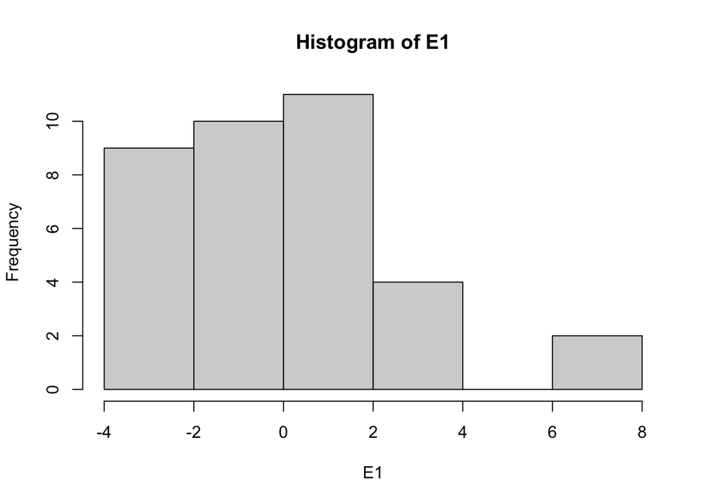

```r
lme.may2018.mod <- lmer(totalsurvival ~ normalized_par + soil_moisture + exotic_percentcover + site + (1|treatment), # <-- DO I NEED TO INCLUDE TREATMENT IF IT WASN'T SIG?
                         data = survmortnospp_may2018_join)

MOD <- lme.may2018.mod

# Calculate model's residual and fitted values
F1 <- fitted(MOD)
E1 <- residuals(MOD, "pearson")

# See residuals as a histogram, look for normal distribution
hist(E1)
```

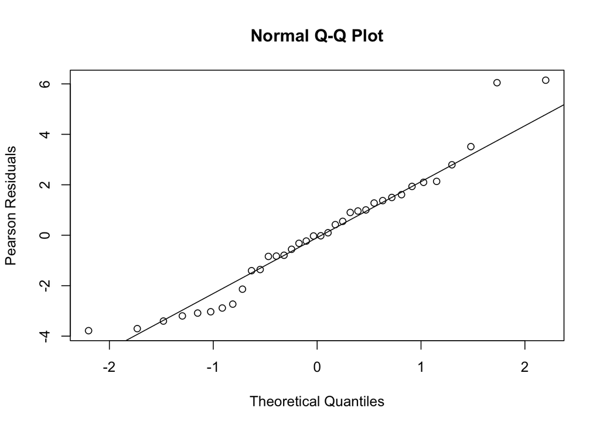

```r
# Graph residuals against a normal distribution, look for all points to be on 1:1 line
#need to call next two lines together
qqnorm(E1, xlab = "Theoretical Quantiles", ylab = "Pearson Residuals")
qqline(E1)
```

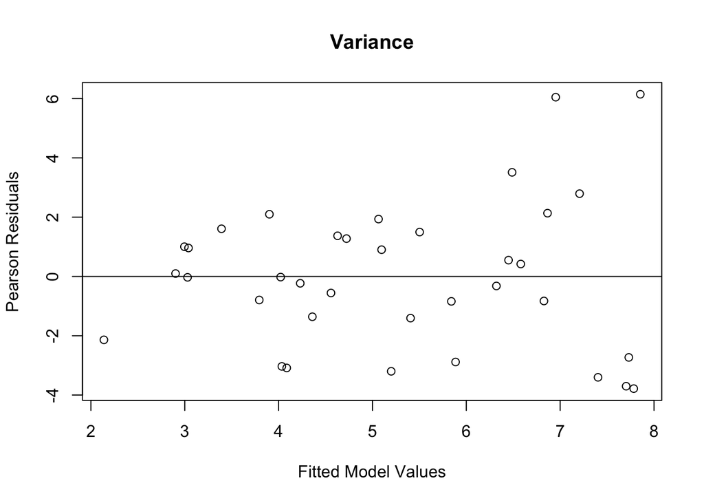

```r
# Graph residuals vs fitted values to inspect homogeneity of variance, look for a random scattering of plots
# run together 2 lines
plot(x=F1, y=E1, xlab="Fitted Model Values", ylab="Pearson Residuals", main = "Variance")
abline(h = 0) # looking for random scatter
```

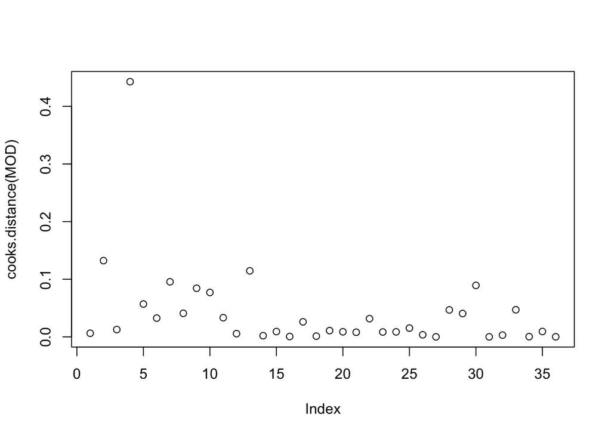

```r
# Check for crazy outliers, look for lines MUCH taller than the rest of data
plot(cooks.distance(MOD))
```

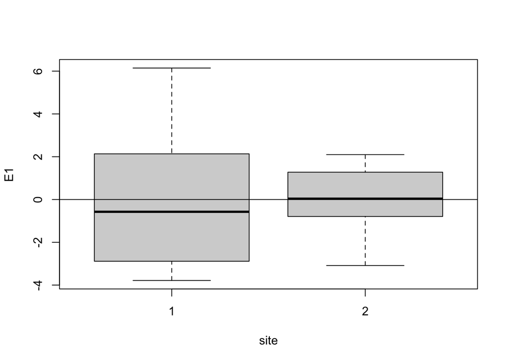

```r
# Plot a box plot for each factor, look for equal variance amount levels along the zero line
# Box plots need to be assessed for every fixed effect (categorical factor) for your model.
# Random effects need the qqline just like normality.
# So, only site and treatment get box plots.
# MAFA cover is a covariate (continuous variable).

boxplot(E1 ~ site, data = survmortnospp_may2018_join) # <---- make sure to change to df, not the lme
abline(h = 0)
```

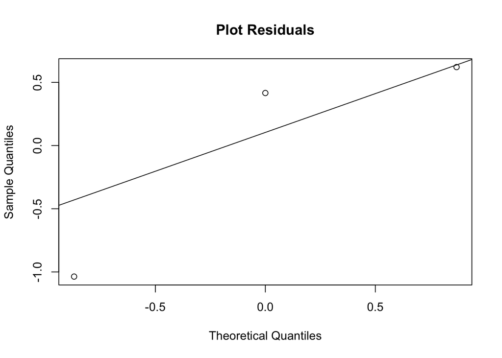

```r
# Plot each random effect in the model - things in the (1|_), look for dots along 1:1 line
qqnorm(ranef(MOD)$treatment[,1], main = "Plot Residuals")
qqline(ranef(MOD)$treatment[,1]) # unique dates
```

- statistics

```r
print(lme.may2018.mod)
```

```
## Linear mixed model fit by REML ['lmerModLmerTest']
## Formula:
## totalsurvival ~ normalized_par + soil_moisture + exotic_percentcover +
##     site + (1 | treatment)
##    Data: survmortnospp_may2018_join
## REML criterion at convergence: 168.6963
## Random effects:
##  Groups    Name        Std.Dev.
##  treatment (Intercept) 1.148
##  Residual              2.682
## Number of obs: 36, groups:  treatment, 3
## Fixed Effects:
##         (Intercept)       normalized_par        soil_moisture
##             5.63125             -1.96941              0.25786
## exotic_percentcover                site2
##            -0.02209             -2.19267
```

```r
summary(lme.may2018.mod)
```

```
## Linear mixed model fit by REML. t-tests use Satterthwaite's method [
## lmerModLmerTest]
## Formula:
## totalsurvival ~ normalized_par + soil_moisture + exotic_percentcover +
##     site + (1 | treatment)
##    Data: survmortnospp_may2018_join
##
## REML criterion at convergence: 168.7
##
## Scaled residuals:
##      Min       1Q   Median       3Q      Max
## -1.41106 -0.59256 -0.00962  0.52319  2.29192
##
## Random effects:
##  Groups    Name        Variance Std.Dev.
##  treatment (Intercept) 1.318    1.148
##  Residual              7.191    2.682
## Number of obs: 36, groups:  treatment, 3
##
## Fixed effects:
##                     Estimate Std. Error       df t value Pr(>|t|)
## (Intercept)          5.63125    5.48097 24.94037   1.027   0.3141
## normalized_par      -1.96941    3.85854 30.99586  -0.510   0.6134
## soil_moisture        0.25786    0.43245 30.83437   0.596   0.5553
## exotic_percentcover -0.02209    0.04493 25.54607  -0.492   0.6272
## site2               -2.19267    1.22861 30.27314  -1.785   0.0843 .
## ---
## Signif. codes:  0 '***' 0.001 '**' 0.01 '*' 0.05 '.' 0.1 ' ' 1
##
## Correlation of Fixed Effects:
##             (Intr) nrmlz_ sl_mst extc_p
## normalzd_pr -0.486
## soil_moistr -0.885  0.155
## extc_prcntc -0.640  0.476  0.306
## site2       -0.603 -0.050  0.667  0.166
```

```r
anova(lme.may2018.mod) # A significant p-value indicates that one or more significant differences exist between group means.
```

```
## Type III Analysis of Variance Table with Satterthwaite's method
##                      Sum Sq Mean Sq NumDF  DenDF F value  Pr(>F)
## normalized_par       1.8734  1.8734     1 30.996  0.2605 0.61338
## soil_moisture        2.5569  2.5569     1 30.834  0.3556 0.55534
## exotic_percentcover  1.7381  1.7381     1 25.546  0.2417 0.62718
## site                22.9048 22.9048     1 30.273  3.1850 0.08434 .
## ---
## Signif. codes:  0 '***' 0.001 '**' 0.01 '*' 0.05 '.' 0.1 ' ' 1
```

```r
# seedling survival is not correlated with par, tdr, exotic percent cover, or site.
# site may be ecologically interesting (p = 0.0843)

# calculate mean survival at Site 1 and Site 2
survmortnospp_may2018_join %>%
  group_by(site) %>%
  summarise(mean_survival=mean(totalsurvival, na.rm = TRUE),
            sd_survival=sd(totalsurvival, na.rm = TRUE))
```

```
## # A tibble: 2 × 3
##   site  mean_survival sd_survival
##   <chr>         <dbl>       <dbl>
## 1 1              6.67        3.36
## 2 2              3.89        1.94
```

- figures

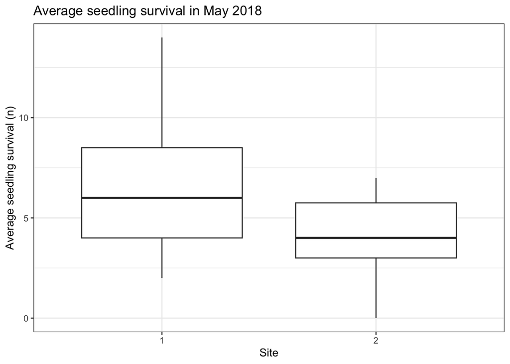

```r
# boxplot: average survival by site
ggplot(data = survmortnospp_may2018_join, aes(x = site, y = totalsurvival)) +
   geom_boxplot(aes(group = site)) +
   labs(title = "Average seedling survival in May 2018", x = "Site", y = "Average seedling survival (n)") +
    theme_bw()
```

# May 2019 Seedling survival

```r
# subsetting data for May 2019 survival
# survmortnospp = may 2019
# par = may 2019
# tdr = march 2019
# nncover = 2019
survmortnospp_may2019 <- dplyr::filter(survmortnospp, year == "2019" & month =="4" | year == "2019" & month =="5")
par_may2019 <- dplyr::filter(par, year == "2019" & month =="5")
tdr_march2019 <- tdr %>%
  dplyr::filter(year == "2019" & month == "3")

tdr_march2019 <- tdr %>%
    dplyr::filter(year == "2019" & month =="3")
nncover_may2019 <- dplyr::filter(exotic_cover_all, year == "2019")
print(survmortnospp_may2019) # each df should have 36 rows of data
```

```
## # A tibble: 36 × 9
##    year  month site  plot_number treatment month_count transpl…¹ total…² total…³
##    <chr> <int> <chr> <chr>       <chr>           <int> <chr>       <int>   <int>
##  1 2019      4 1     1           none               15 2019            7       4
##  2 2019      4 1     13          full               15 2019           10       1
##  3 2019      4 1     15          half               15 2019            3       8
##  4 2019      4 1     16          full               15 2019            7       4
##  5 2019      4 1     17          half               15 2019            8       3
##  6 2019      4 1     2           full               15 2019           10       1
##  7 2019      4 1     3           full               15 2019           11       0
##  8 2019      4 1     4           half               15 2019            5       6
##  9 2019      4 1     5           half               15 2019           11       0
## 10 2019      4 1     6           none               15 2019            9       2
## # … with 26 more rows, and abbreviated variable names ¹transplanted,
## #   ²totalsurvival, ³totalmortality
```

```r
# left join data for may 2019 survival
survmortnospp_may2019_join <- survmortnospp_may2019 %>%
  dplyr::left_join(par_may2019, by = c("year", "site", "plot_number", "treatment"), na.rm = F) %>%    #left join par
  rename(month_survival = month.x,
         month_par = month.y) %>%
  dplyr::left_join(par_may2019, by = c("year", "site", "plot_number"), na.rm = F) %>%   # left join tdr
  rename(treatment = treatment.x,
         month_tdr = month) %>%
  dplyr::select(!treatment.y) %>%
   dplyr::left_join(nncover_may2019, by = c("year", "site", "plot_number"), na.rm = F) %>%   # left join exotic percent cover
  rename(exotic_percentcover = cover_percent) %>%
  dplyr::select(!treatment.y) %>%
  dplyr::select(!date)
view(survmortnospp_may2019_join)
```